# Introduction to Generative AI: Beyond the Chat

Workshop 1 notes: learning to work with AI coding agents

This workshop took place on Friday, October 16, 2026, at [Colorado State University](https://www.colostate.edu). This page recaps the slides, gives a short overview of the live demo, and points you to other resources. Workshop 1 was designed for those with zero prior experience. If you want to go further, consider Workshop 2.

# What is an AI coding agent?

### Chat

You paste in what you want it to do and get code back. Then you copy it, run it, fix it, and paste it in again.

### An agent

You say *“clean this survey export and merge it with the state data,”* and it opens the files, writes the script, runs it and checks the result.

The two main tools are **Claude Code** (Anthropic) and **Codex** (OpenAI). Everything from the workshop works in either one.

## Why use one?

- **Write code fast.** Go from a research question to code.
- **Handle the mundane.** Hand off data cleaning, reshaping, merging and recoding variables.
- **Automate repetitive tasks.** Run the same analysis across many datasets, models or specifications.
- **Lower the barrier to entry.** Use tools you don’t have expertise in.
- **Apply best practices.** Get guidance on standard errors, model diagnostics and robust specifications.
- **Improve replicability.** The code it writes is commented and documented, so every step of the analysis can be seen.

**Something to think about**

Which tasks in your own work take the most time but the least judgment?

## Think of AI as a research assistant

- It’s fast, tireless, and good at routine tasks.
- But it makes mistakes, so check its work.
- It needs clear direction and correction.
- It doesn’t always know what to do, and sometimes it tries anyway.
- **You are still the researcher.** You’re responsible for the design, the interpretation and the conclusions.

## Potential applications

| Area | Examples |
| --- | --- |
| **Text and corpus work** | Word frequencies, concordances or topic comparisons across a folder of novels, speeches or interview transcripts |
| **Messy data** | Cleaning survey exports, merging spreadsheets, fixing inconsistent coding |
| **Document wrangling** | Renaming and organizing hundreds of PDFs or scans, extracting text, converting citation formats |
| **Social science analysis** | Analysis scripts, with explanations |
| **Writing** | Summarizing and interpreting results, and more |

# Ethical considerations

### Data sensitivity

- Your files stay on your computer, but **anything the agent reads is sent to the model.**
- It isn’t always clear how secure the data is once it reaches the company.
- You may not be allowed to share your data with an agent (for example, under your IRB protocol).
- In the long run, models that run locally may solve this.

### Disclosure and authorship

- Most publishers say AI can’t be an author and that its use should be disclosed.
- Disclosure norms are uneven and changing fast.
- It’s also unclear how well people follow those norms.
- **You’re responsible for your work, whoever or whatever drafted it.**

# The workshop example

The goal was to work through a “complete” data project with an AI agent. Time was short, so treat what you saw as an introduction, not as best practice. The point was to give you enough understanding to explore further.

### Research hypotheses and questions

Based on Gelman et al., *Red State, Blue State, Rich State, Poor State* (2008):

1. Richer states vote more Democratic.
2. Within states, richer people vote more Republican.
3. The income gap in voting Republican is steeper in poor states than in rich ones.
4. Did this change between 2020 and 2024?
5. Does it depend on the respondent’s sex, race or education?

We used a 5,000-person sample per year from the **Cooperative Election Study (CES)**, plus state median income (Census CPS) and state vote shares (MIT Election Lab).

[figure not shown]

# Working with an agent

## First steps

- **Work in a dedicated folder.** The folder you start the agent in is its whole world.
- **You may need to grant permissions.** It asks before editing files or running commands. Read what it asks before you approve.
- **Choose the model and effort level.** Bigger models and more effort help with hard problems but are slower and use your allowance faster.
- **Give it standing context** in `CLAUDE.md` (Claude Code) or `AGENTS.md` (Codex).

## Memos

Write the project’s memory to files, not the conversation.

| File | Who it’s for | What it holds |
| --- | --- | --- |
| `README.md` / `NOTES.md` | Humans | What the project is and how it was built |
| `CLAUDE.md` or `AGENTS.md` | The agent | How to behave in this project |
| `PROGRESS.md` | Both | Where things stand and what’s next |

## Context windows

Long conversations:

- get muddled,
- forget the original goal,
- and can use up a lot of tokens.

**Compact or clear.** `/compact` summarizes the conversation so far. `/clear` (Claude Code) or `/new` (Codex) starts a blank one. Either way, **use the memos**: a fresh session can read `NOTES.md` and `PROGRESS.md` and pick up where you left off.

**Quick reference: Claude Code vs. Codex commands**

| What you want | Claude Code | Codex |
| --- | --- | --- |
| Start in the current folder | `claude` | `codex` |
| Standing instructions file | `CLAUDE.md` | `AGENTS.md` |
| Draft an instructions file | `/init` | `/init` |
| Choose model and effort | `/model`, `/effort` | `/model` |
| Change permissions | `Shift+Tab` | `/permissions` |
| Point at a specific file | `@file` | `@file` |
| See how full the context is | `/context` | `/status` |
| Summarize to free up space | `/compact` | `/compact` |
| Start a blank conversation | `/clear` | `/new` |
| Reopen an earlier session | `claude --resume` | `codex resume` |

Both tools change often, so check the current documentation.

# Overview of the demo analysis

The live demo ran in two sessions, with a `/clear` in between.

**Session 1** got the data together. The agent read the CES file and flagged quirks (vote codes that mean different things in 2020 and 2024, “prefer not to say” coded as income). It found and downloaded state income and vote share data, merged everything, and organized the folder into `data/`, `analysis/` and `results/`. Before stopping, we had it write `NOTES.md` and `PROGRESS.md`.

**Session 2** began with *“Where did I leave off?”* From there it cleaned the data, produced descriptives, fit multilevel models, split the results by race, and ran robustness checks. It finished with a draft R Markdown report.

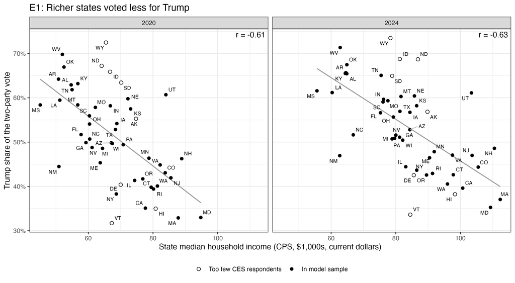

Richer states voted less for Trump in both years.

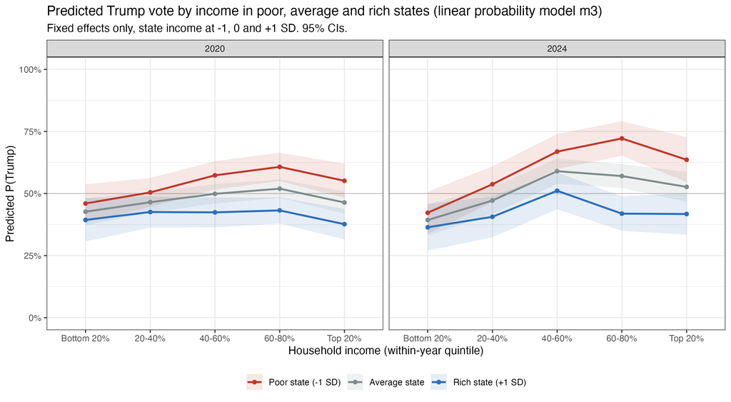

Within states, the income gap in Trump support is steeper in poor states than in rich ones.

**What we found, in brief:** richer states voted less for Trump. Within states, the income pattern was weak. The steeper income gap in poorer states held up in the weighted models but was about half as large, and not significant, without weights.

**The lesson**

The agent made the analysis “easy” but **deciding what it means is still your job.**

# Future steps

What would come next for a project like this:

- **Verification.** Check results against numbers you already know, and open every source it cites.
- **More data and analyses.** For example, ACS income in place of CPS, trimmed weights, or education interactions.
- **Further extensions.**
- **Writing a paper:** framing, literature review, data and methods, results.

# Next steps

## Workshop 2

Workshop 2

### Vibe Coding: Data Curation & Analysis with Generative AI

Building, debugging, and auditing data scripts with AI

November 13 2:00–4:00 p.m. Lory Student Center, Room 304–06

A hands-on introduction to using AI-integrated IDEs and coding agents to write, debug, and audit code for data preparation and analysis. We’ll cover:

- Evaluating code that handles sensitive data
- Using Claude Code within RStudio for interactive coding
- Building a web scraper with Claude Code/Codex and Python, including MCPs and Skills

[RSVP for Workshop 2](https://colostate.az1.qualtrics.com/jfe/form/SV_0Nu6h7Q7m0BmGP4)

## Resources

### Other introductions

- [Getting Started with Claude Code: A Researcher’s Setup Guide](https://paulgp.substack.com/p/getting-started-with-claude-code) (Paul Goldsmith-Pinkham)
- [Agentic AI for Social Science Research](https://bgpopescu.net/teaching/agentic/) (Bogdan G. Popescu)
- [Claude Code: From Zero to Mastery](https://toyibaremu.github.io/claude-learn/index.html)
- [AI Agents for Economics Research](https://aieconomist.io/tutorials/ai-agents-for-economics-research) (The AI Economist)

### Data used in the demo

- [Cooperative Election Study (CES)](https://cces.gov.harvard.edu/)
- [MIT Election Data and Science Lab](https://electionlab.mit.edu/data)
- [Census CPS historical income tables (Table H-8)](https://www.census.gov/data/tables/time-series/demo/income-poverty/historical-income-households.html)

### Background reading

- Gelman, A., Park, D., Shor, B., Bafumi, J., & Cortina, J. (2008). *[Red State, Blue State, Rich State, Poor State: Why Americans Vote the Way They Do](https://press.princeton.edu/books/paperback/9780691143934/red-state-blue-state-rich-state-poor-state)*. Princeton University Press.

# Get in touch

If you’ve read this far, you must really be interested in computational social science! If you’d like to see more of this at CSU, or just want to get in touch, please [contact me](https://ophastings.com).